# Day 3 lectures and exercises

The following is for my own benefit. You do not need to run this.

```r
rm(list=ls())
```

Today, you will analyze some data sets that have a mix of categorical and continuous variables.

## read in the pu data set

```r
fn <- "http://www.amstat.org/publications/jse/datasets/fev.dat.txt"
pu <- read.table(file=fn)
head(pu)
```

```
##   V1    V2   V3 V4 V5
## 1  9 1.708 57.0  0  0
## 2  8 1.724 67.5  0  0
## 3  7 1.720 54.5  0  0
## 4  9 1.558 53.0  1  0
## 5  9 1.895 57.0  1  0
## 6  8 2.336 61.0  0  0
```

```r
tail(pu)
```

```
##     V1    V2   V3 V4 V5
## 649 16 4.872 72.0  1  1
## 650 16 4.270 67.0  1  1
## 651 15 3.727 68.0  1  1
## 652 18 2.853 60.0  0  0
## 653 16 2.795 63.0  0  1
## 654 15 3.211 66.5  0  0
```

Since the file looks good, let’s save a local copy.

```r
write.csv(pu,file="day3_fev.txt",row.names=FALSE,col.names=FALSE)
```

## Assign names and create factors

You should assign names to each column of data and convert the columns with numeric codes into factors

```r
names(pu) <- c("age","fev","ht","sex","smoke")
pu$smoke.factor <- factor(pu$smoke,levels=0:1,
                          labels=c("nonsmoker","smoker"))
```

## On your own

Create a factor for sex.

## Summary for the pu variables

There is a mix of categorical and continuous variables in this data set, but the summary function should work for all of them.

```r
summary(pu)
```

```
##       age              fev              ht             sex
##  Min.   : 3.000   Min.   :0.791   Min.   :46.00   Min.   :0.0000
##  1st Qu.: 8.000   1st Qu.:1.981   1st Qu.:57.00   1st Qu.:0.0000
##  Median :10.000   Median :2.547   Median :61.50   Median :1.0000
##  Mean   : 9.931   Mean   :2.637   Mean   :61.14   Mean   :0.5138
##  3rd Qu.:12.000   3rd Qu.:3.119   3rd Qu.:65.50   3rd Qu.:1.0000
##  Max.   :19.000   Max.   :5.793   Max.   :74.00   Max.   :1.0000
##      smoke            smoke.factor
##  Min.   :0.00000   nonsmoker:589
##  1st Qu.:0.00000   smoker   : 65
##  Median :0.00000
##  Mean   :0.09939
##  3rd Qu.:0.00000
##  Max.   :1.00000
```

## On your own

Calculate correlations among age, ht, and fev.

## Scatterplot

Recall that you use a scatterplot to examine the relationship between two continuous variables.

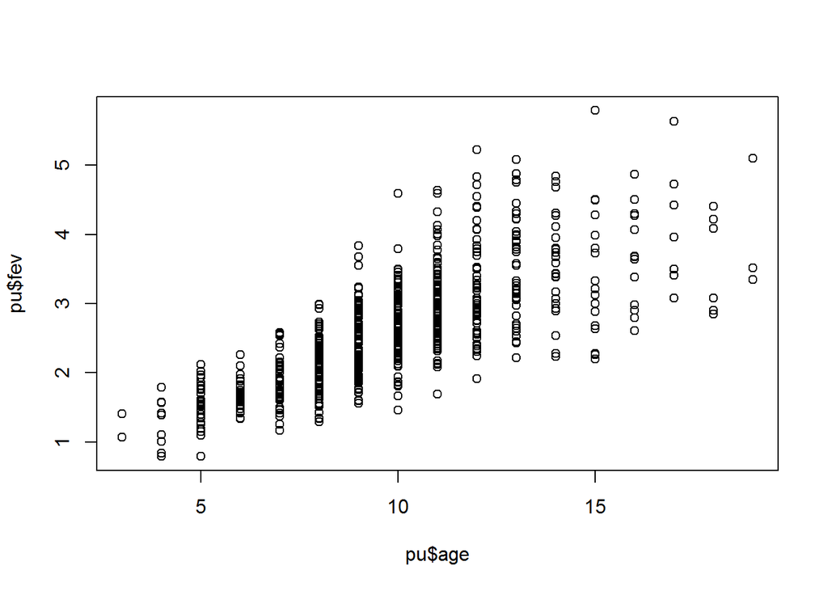

```r
plot(pu$age,pu$fev)
```

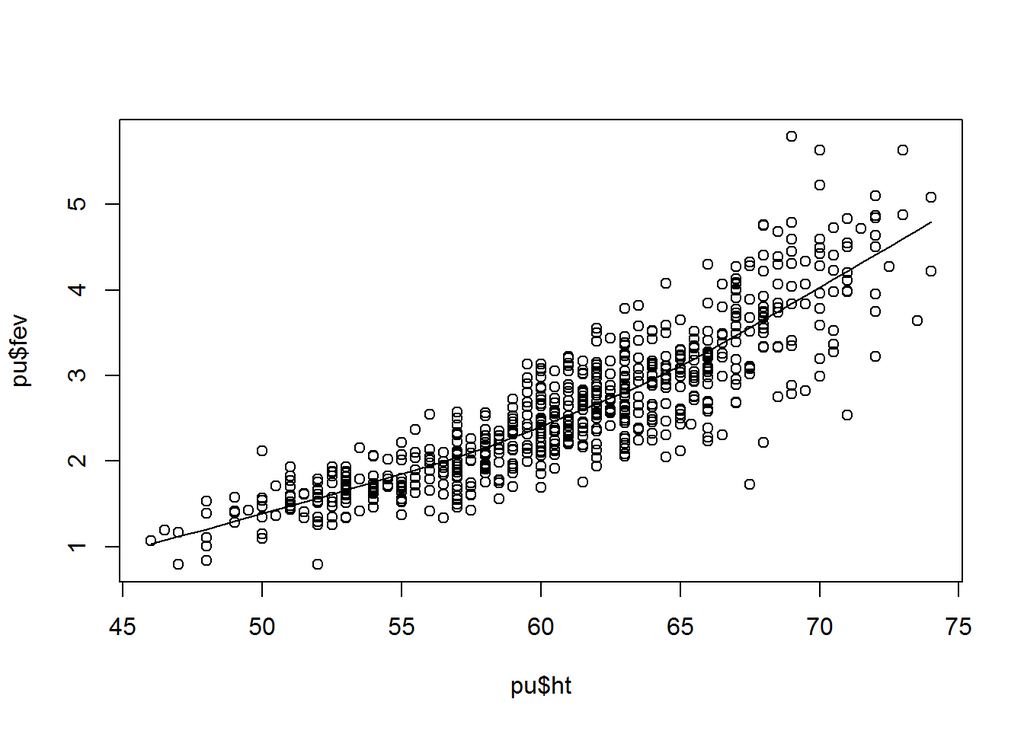

```r
plot(pu$ht,pu$fev)
smooth.curve <- lowess(pu$ht,pu$fev)
lines(smooth.curve)
```

## On your own

Draw a scatterplot for age and fev. Add a linear regression trend line to this graph.

## crosstabs

Also recall that you use a crosstabulation to examine the relationship between two categorical variables.

```r
table(pu$sex,pu$smoke.factor)
```

```
##
##     nonsmoker smoker
##   0       279     39
##   1       310     26
```

```r
prop.table(table(pu$sex,pu$smoke.factor),margin=1)
```

```
##
##      nonsmoker     smoker
##   0 0.87735849 0.12264151
##   1 0.92261905 0.07738095
```

## boxplots

When you want to look at a relationship between a categorical variable and a continuous variable, you should use a boxplot.

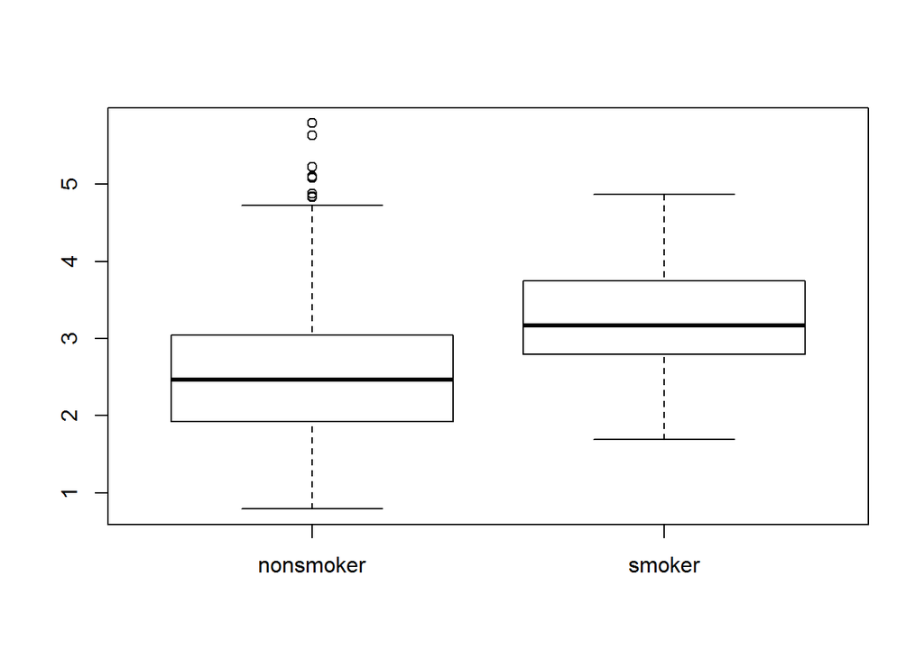

```r
boxplot(fev~smoke.factor,data=pu)
```

This is very odd. You can get a hint as to why smokers might have higher fev values than non-smokers by looking at how age and smoking status are related.

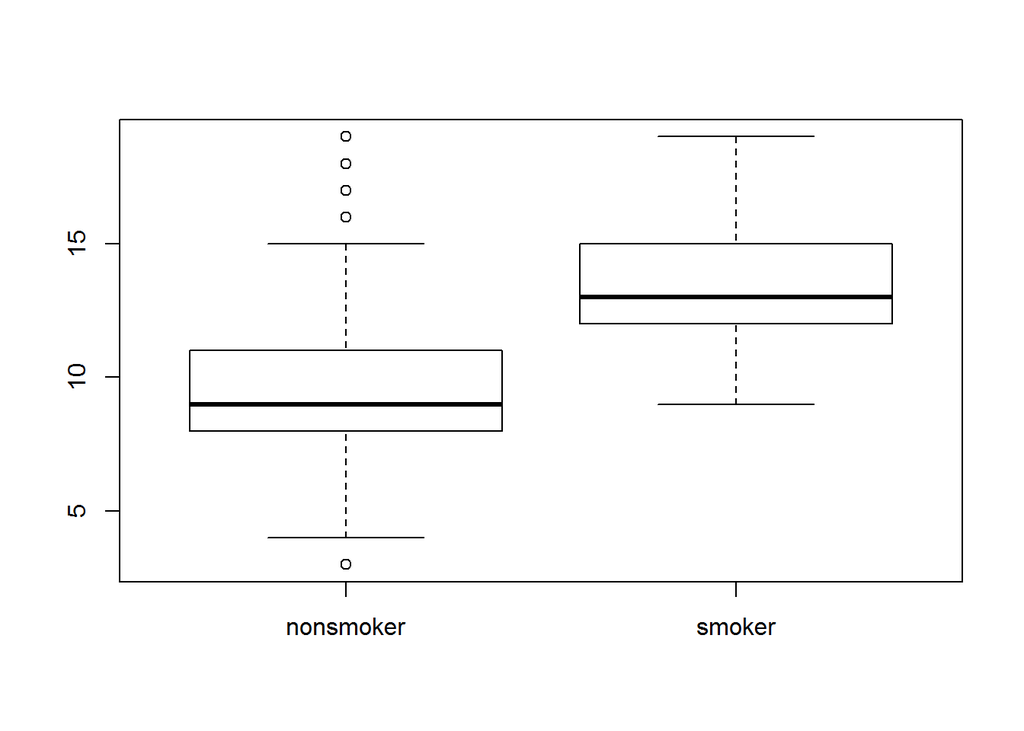

```r
boxplot(age~smoke.factor,data=pu)
```

## On your own

Look at the relationship between sex and fev.

## Means and standard deviations by group

You should also calculate the means for each continuous variable within each level of the categorical variable.

Note: you don’t really need the na.rm=TRUE argument here, but you might in other examples.

```r
# fev mean by smoke.factor
by(pu$fev,pu$smoke.factor,mean,na.rm=TRUE)
```

```
## pu$smoke.factor: nonsmoker
## [1] 2.566143
## --------------------------------------------------------
## pu$smoke.factor: smoker
## [1] 3.276862
```

```r
# fev standard deviation by smoke.factor
by(pu$fev,pu$smoke.factor,sd,na.rm=TRUE)
```

```
## pu$smoke.factor: nonsmoker
## [1] 0.8505215
## --------------------------------------------------------
## pu$smoke.factor: smoker
## [1] 0.7499863
```

The output is not labelled all that clearly, but you can use the paste function to make things look nicer.

```r
grp.means <- by(pu$fev,pu$smoke.factor,mean)
grp.stdev <- by(pu$fev,pu$smoke.factor,sd)
colon <- ": "
plus.minus <- "+/-"
paste(names(grp.means),colon,round(grp.means,1),
      plus.minus,round(grp.stdev,1),sep="")
```

```
## [1] "nonsmoker: 2.6+/-0.9" "smoker: 3.3+/-0.7"
```

Let’s calculate mean ages for smokers and nonsmokers. Notice that smokers are 4 years older on average than nonsmokers.

```r
grp.means <- by(pu$age,pu$smoke.factor,mean)
grp.stdev <- by(pu$age,pu$smoke.factor,sd)
colon <- ": "
plus.minus <- "+/-"
paste(names(grp.means),colon,round(grp.means,1),
      plus.minus,round(grp.stdev,1),sep="")
```

```
## [1] "nonsmoker: 9.5+/-2.7" "smoker: 13.5+/-2.3"
```

## On your own

Compute the mean and standard deviation for fev by sex.

## Read in the housing data set

You should find the data file on housing prices in Albuquerque at –> http://lib.stat.cmu.edu/DASL/Datafiles/homedat.html

You should cut-and-paste the actual data to notepad and save it with the name housing.txt. You need to read in the file using the read.table function.

For technical reasons, you want the as.is=TRUE argument. Otherwise AGe and TAX are converted to factors which causes all sorts of grief.

```r
al <- read.table(file="day3_housing.txt",header=TRUE,as.is=TRUE)
head(al)
```

```
##   PRICE SQFT AGE FEATS NE CUST COR  TAX
## 1  2050 2650  13     7  1    1   0 1639
## 2  2080 2600   *     4  1    1   0 1088
## 3  2150 2664   6     5  1    1   0 1193
## 4  2150 2921   3     6  1    1   0 1635
## 5  1999 2580   4     4  1    1   0 1732
## 6  1900 2580   4     4  1    0   0 1534
```

```r
tail(al)
```

```
##     PRICE SQFT AGE FEATS NE CUST COR TAX
## 112   874 1236   3     4  0    0   0 707
## 113   872 1229   6     3  0    0   0 721
## 114   870 1273   4     4  0    0   0 638
## 115   869 1165   7     4  0    0   0 694
## 116   766 1200   7     4  0    0   1 634
## 117   739  970   4     4  0    0   1 541
```

```r
summary(al)
```

```
##      PRICE           SQFT          AGE                FEATS
##  Min.   : 540   Min.   : 837   Length:117         Min.   :0.00
##  1st Qu.: 780   1st Qu.:1280   Class :character   1st Qu.:3.00
##  Median : 960   Median :1549   Mode  :character   Median :4.00
##  Mean   :1063   Mean   :1654                      Mean   :3.53
##  3rd Qu.:1200   3rd Qu.:1894                      3rd Qu.:4.00
##  Max.   :2150   Max.   :3750                      Max.   :8.00
##        NE              CUST             COR            TAX
##  Min.   :0.0000   Min.   :0.0000   Min.   :0.000   Length:117
##  1st Qu.:0.0000   1st Qu.:0.0000   1st Qu.:0.000   Class :character
##  Median :1.0000   Median :0.0000   Median :0.000   Mode  :character
##  Mean   :0.6667   Mean   :0.2308   Mean   :0.188
##  3rd Qu.:1.0000   3rd Qu.:0.0000   3rd Qu.:0.000
##  Max.   :1.0000   Max.   :1.0000   Max.   :1.000
```

There is a problem with AGE. The person who entered the data intended for an asterisk to represent a missing value. But R interpreted the asterisk as a string and converted all the numeric ages to strings also. That’s why R summarizes age using counts rather than means. Use the as.numeric function to fix this.

A side effect, which is desired in this case, is that anything that cannot be converted from a string to a number (like an asterisk) is instead converted to a missing value.

```r
al$age.years <- as.numeric(al$AGE)
summary(al$age.years)
```

```
##    Min. 1st Qu.  Median    Mean 3rd Qu.    Max.    NA's
##    1.00    5.75   13.00   14.97   19.25   53.00      49
```

There is a mix of categorical and continuous variables. Recall that you use a scatterplot to examine the relationship between two continuous variables, a crosstabls and an odds ratio to examine the relationship between two categorical variables, and a boxplot to examine the relationship between a categorical variable and a continuous variable.

## On your own

1. Convert the asterisks in the TAX variable to missing. How many missing values are there for AGE and for TAX?
2. Create factors for NE, CUST, and COR. Draw bar charts for each of these factors.
3. Find the largest house (biggest SQFT) in the data set. Is the largest house also the most expensive house?
4. Calculate frequency counts for FEATS. Are there any houses with the no features? Are there any houses with every possible feature?
5. Evaluate the relationship between PRICE and SQFT using a scatterplot. Include a smooth curve. Do larger houses tend to cost more?
6. Evaluate the relationship between CUST and PRICE using a boxplot. Calculate the mean price and standard deviation by CUST.
7. What is the difference in average prices between northeast houses and other houses? What is the difference in average taxes?
8. Are custombuilt houses more likely to appear on corner lots? Calculate the percentages and compute a relative risk.
9. Place all the key results into a Word document, add a bit of commentary, and turn it in.

## A third data set

If there is time, we can explore a third data set, diamond prices. The data is at

–> http://www.amstat.org/publications/jse/v9n2/4cdata.txt

and a description is at

–> http://www.amstat.org/publications/jse/v9n2/4c.txt

## Save all my work

```r
save.image("day3.RData")
```